# Marketing Campaign Performance Optimization using Python and Power BI

```python
import pandas as pd
import numpy as np
```

```python
df = pd.read_csv("GoogleAds_DataAnalytics_Sales_Uncleaned.csv") # Load Data in Python
```

```python
df.head()
```

|  | Ad_ID | Campaign_Name | Clicks | Impressions | Cost | Leads | Conversions | Conversion Rate | Sale_Amount | Ad_Date | Location | Device | Keyword |
| --- | --- | --- | --- | --- | --- | --- | --- | --- | --- | --- | --- | --- | --- |
| 0 | A1000 | DataAnalyticsCourse | 104.0 | 4498.0 | $231.88 | 14.0 | 7.0 | 0.058 | $1892 | 2024-11-16 | hyderabad | desktop | learn data analytics |
| 1 | A1001 | DataAnalyticsCourse | 173.0 | 5107.0 | $216.84 | 10.0 | 8.0 | 0.046 | $1679 | 20-11-2024 | hyderabad | mobile | data analytics course |
| 2 | A1002 | Data Anlytics Corse | 90.0 | 4544.0 | $203.66 | 26.0 | 9.0 | NaN | $1624 | 2024/11/16 | hyderabad | Desktop | data analitics online |
| 3 | A1003 | Data Analytcis Course | 142.0 | 3185.0 | $237.66 | 17.0 | 6.0 | NaN | $1225 | 2024-11-26 | HYDERABAD | tablet | data anaytics training |
| 4 | A1004 | Data Analytics Corse | 156.0 | 3361.0 | $195.9 | 30.0 | 8.0 | NaN | $1091 | 2024-11-22 | hyderabad | desktop | online data analytic |

```python
df.describe()
```

|  | Clicks | Impressions | Leads | Conversions | Conversion Rate |
| --- | --- | --- | --- | --- | --- |
| count | 2488.000000 | 2546.000000 | 2552.000000 | 2526.000000 | 1974.000000 |
| mean | 138.956994 | 4523.280833 | 20.003918 | 6.519002 | 0.048979 |
| std | 34.619376 | 869.927913 | 6.032317 | 2.272573 | 0.019987 |
| min | 80.000000 | 3000.000000 | 10.000000 | 3.000000 | 0.015000 |
| 25% | 110.000000 | 3764.000000 | 15.000000 | 5.000000 | 0.035000 |
| 50% | 139.000000 | 4518.500000 | 20.000000 | 7.000000 | 0.046000 |
| 75% | 169.000000 | 5279.500000 | 25.000000 | 9.000000 | 0.058000 |
| max | 199.000000 | 5999.000000 | 30.000000 | 10.000000 | 0.123000 |

```python
df['Cost'].head(10)
```

```
0    $231.88
1    $216.84
2    $203.66
3    $237.66
4     $195.9
5    $243.57
6    $237.79
7    $229.61
8        NaN
9    $186.78
Name: Cost, dtype: object
```

```python
df.info()
```

```
<class 'pandas.core.frame.DataFrame'>
RangeIndex: 2600 entries, 0 to 2599
Data columns (total 13 columns):
 #   Column           Non-Null Count  Dtype
---  ------           --------------  -----
 0   Ad_ID            2600 non-null   object
 1   Campaign_Name    2600 non-null   object
 2   Clicks           2488 non-null   float64
 3   Impressions      2546 non-null   float64
 4   Cost             2503 non-null   object
 5   Leads            2552 non-null   float64
 6   Conversions      2526 non-null   float64
 7   Conversion Rate  1974 non-null   float64
 8   Sale_Amount      2461 non-null   object
 9   Ad_Date          2600 non-null   object
 10  Location         2600 non-null   object
 11  Device           2600 non-null   object
 12  Keyword          2600 non-null   object
dtypes: float64(5), object(8)
memory usage: 264.2+ KB
```

```python
df.isnull().sum()
```

```
Ad_ID                0
Campaign_Name        0
Clicks             112
Impressions         54
Cost                97
Leads               48
Conversions         74
Conversion Rate    626
Sale_Amount        139
Ad_Date              0
Location             0
Device               0
Keyword              0
dtype: int64
```

```python
df.duplicated().sum()
```

```
np.int64(0)
```

Data Cleaning

Campaign name spelling errors

Device capitalization

Date formatting

Missing values

```python
pip install rapidfuzz
```

```python
from rapidfuzz import process # Automatic Spell Correction

unique_campaigns = df['Campaign_Name'].unique()

print(unique_campaigns)
```

```
['DataAnalyticsCourse' 'Data Anlytics Corse' 'Data Analytcis Course'
 'Data Analytics Corse']
```

```python
df['Campaign_Name'] = df['Campaign_Name'].str.lower()
```

```python
df['Campaign_Name'] = df['Campaign_Name'].str.replace("DataAnalyticsCourse","Data analytics Course")
df['Campaign_Name'] = df['Campaign_Name'].str.replace("Data Anlytics Corse","Data analytics Course")
df['Campaign_Name'] = df['Campaign_Name'].str.replace("Data Analytcis Course","Data analytics Course")
df['Campaign_Name'] = df['Campaign_Name'].str.replace("Data Analytics Corse","Data analytics Course")
```

```python
df['Campaign_Name']
```

[output not shown]

```python
df['Campaign_Name'] = (
    df['Campaign_Name']
    .str.lower()
    .str.replace('corse', 'course')
    .str.replace('dataanalyticscourse', 'data analytics course')
)
```

```python
df['Campaign_Name'].unique()
```

```
array(['data analytics course', 'data anlytics course',
       'data analytcis course'], dtype=object)
```

```python
df['Campaign_Name']
```

```
0       data analytics course
1       data analytics course
2        data anlytics course
3       data analytcis course
4       data analytics course
                ...
2595    data analytics course
2596    data analytics course
2597     data anlytics course
2598    data analytics course
2599    data analytics course
Name: Campaign_Name, Length: 2600, dtype: object
```

```python
df['Device'] = df['Device'].str.lower()
```

```python
df['Device'].head()
```

```
0    desktop
1     mobile
2    desktop
3     tablet
4    desktop
Name: Device, dtype: object
```

```python
df['Ad_Date'] = pd.to_datetime(df['Ad_Date'], format='mixed', dayfirst=True)
```

```python
df['Ad_Date']
```

```
0      2024-11-16
1      2024-11-20
2      2024-11-16
3      2024-11-26
4      2024-11-22
          ...
2595   2024-11-29
2596   2024-11-28
2597   2024-11-02
2598   2024-11-08
2599   2024-11-22
Name: Ad_Date, Length: 2600, dtype: datetime64[ns]
```

```python
df = df.drop_duplicates()
```

```python
df.head()
```

|  | Ad_ID | Campaign_Name | Clicks | Impressions | Cost | Leads | Conversions | Conversion Rate | Sale_Amount | Ad_Date | Location | Device | Keyword |
| --- | --- | --- | --- | --- | --- | --- | --- | --- | --- | --- | --- | --- | --- |
| 0 | A1000 | data analytics course | 104.0 | 4498.0 | $231.88 | 14.0 | 7.0 | 0.058 | $1892 | 2024-11-16 | hyderabad | desktop | learn data analytics |
| 1 | A1001 | data analytics course | 173.0 | 5107.0 | $216.84 | 10.0 | 8.0 | 0.046 | $1679 | 2024-11-20 | hyderabad | mobile | data analytics course |
| 2 | A1002 | data anlytics course | 90.0 | 4544.0 | $203.66 | 26.0 | 9.0 | NaN | $1624 | 2024-11-16 | hyderabad | desktop | data analitics online |
| 3 | A1003 | data analytcis course | 142.0 | 3185.0 | $237.66 | 17.0 | 6.0 | NaN | $1225 | 2024-11-26 | HYDERABAD | tablet | data anaytics training |
| 4 | A1004 | data analytics course | 156.0 | 3361.0 | $195.9 | 30.0 | 8.0 | NaN | $1091 | 2024-11-22 | hyderabad | desktop | online data analytic |

Feature Engineering (Marketing KPIs)

Click Through Rate (CTR) # CTR = Clicks / Impressions

```python
df['CTR'] = df['Clicks'] / df['Impressions']
df['CTR']
```

```
0       0.023121
1       0.033875
2       0.019806
3       0.044584
4       0.046415
          ...
2595    0.016467
2596    0.047960
2597    0.029674
2598    0.033487
2599         NaN
Name: CTR, Length: 2600, dtype: float64
```

Cost Per Click (CPC) # CPC = Cost / Clicks

df.dtypes # column shows object, it usually means it contains strings.

```python
df['Cost'].head(10)
```

```
0    $231.88
1    $216.84
2    $203.66
3    $237.66
4     $195.9
5    $243.57
6    $237.79
7    $229.61
8        NaN
9    $186.78
Name: Cost, dtype: object
```

```python
df['Cost'] = df['Cost'].replace('[£$,]', '', regex=True)
```

```python
df['Cost']
```

```
0       231.88
1       216.84
2       203.66
3       237.66
4        195.9
         ...
2595    242.07
2596    248.28
2597    233.25
2598    220.13
2599       NaN
Name: Cost, Length: 2600, dtype: object
```

```python
df['Cost'] = pd.to_numeric(df['Cost'], errors='coerce')
```

```python
df['Cost'].head()
```

```
0    231.88
1    216.84
2    203.66
3    237.66
4    195.90
Name: Cost, dtype: float64
```

```python
df['CPC'] = df['Cost'] / df['Clicks']
df['CPC'].head()
```

```
0    2.229615
1    1.253410
2    2.262889
3    1.673662
4    1.255769
Name: CPC, dtype: float64
```

Cost Per Acquisition (CPA) # CPA = Cost / Conversions

```python
df['CPA'] = df['Cost'] / df['Conversions']
df['CPA'].head()
```

```
0    33.125714
1    27.105000
2    22.628889
3    39.610000
4    24.487500
Name: CPA, dtype: float64
```

Return On Ad Spend (ROAS) #ROAS = Sale Amount / Cost

```python
df['Sale_Amount'] = df['Sale_Amount'].replace('[£$,]', '', regex=True)
```

```python
df['Sale_Amount'].head()
```

```
0    1892
1    1679
2    1624
3    1225
4    1091
Name: Sale_Amount, dtype: object
```

```python
df['Sale_Amount'] = pd.to_numeric(df['Sale_Amount'], errors='coerce')
```

```python
df['Sale_Amount'].head()
```

```
0    1892.0
1    1679.0
2    1624.0
3    1225.0
4    1091.0
Name: Sale_Amount, dtype: float64
```

```python
df['ROAS'] = df['Sale_Amount'] / df['Cost']
```

```python
df['ROAS'].head()
```

```
0    8.159393
1    7.743036
2    7.974074
3    5.154422
4    5.569168
Name: ROAS, dtype: float64
```

Exploratory Data Analysis (EDA)

```python
df.groupby('Campaign_Name')[['Clicks','Conversions','Sale_Amount','Cost']].sum()
```

| Campaign_Name | Clicks | Conversions | Sale_Amount | Cost |
| --- | --- | --- | --- | --- |
| data analytcis course | 88345.0 | 4326.0 | 962574.0 | 140963.60 |
| data analytics course | 172824.0 | 8147.0 | 1833214.0 | 267239.85 |
| data anlytics course | 84556.0 | 3994.0 | 892385.0 | 130168.38 |

```python
# Device Performance

df.groupby('Device')[['Conversions','Cost','Sale_Amount']].sum()
```

| Device | Conversions | Cost | Sale_Amount |
| --- | --- | --- | --- |
| desktop | 5632.0 | 183786.04 | 1264233.0 |
| mobile | 5645.0 | 183558.31 | 1235809.0 |
| tablet | 5190.0 | 171027.48 | 1188131.0 |

```python
# Location Performance

df.groupby('Location')['Sale_Amount'].sum().sort_values(ascending=False)
```

```
Location
HYDERABAD    936104.0
hyderabad    927793.0
Hyderbad     920268.0
hydrebad     904008.0
Name: Sale_Amount, dtype: float64
```

```python
# Best Keywords

df.groupby('Keyword')['Conversions'].sum().sort_values(ascending=False).head(10)
```

```
Keyword
online data analytic      2869.0
learn data analytics      2823.0
data analytics course     2806.0
analytics for data        2687.0
data anaytics training    2654.0
data analitics online     2628.0
Name: Conversions, dtype: float64
```

Export Clean Data for Power BI

```python
df.to_csv("cleaned_marketing_data.csv", index=False)
```

Advanced Optimization

```python
df['Conversions'].isnull().sum()
```

```
np.int64(74)
```

```python
df['Conversions'] = df['Conversions'].fillna(df['Conversions'].median())
```

```python
df['Conversions'].head()
```

```
0    7.0
1    8.0
2    9.0
3    6.0
4    8.0
Name: Conversions, dtype: float64
```

```python
from sklearn.model_selection import train_test_split
from sklearn.ensemble import RandomForestRegressor
```

```python
X = df[['Clicks','Impressions','Cost']]
y = df['Conversions']

X_train, X_test, y_train, y_test = train_test_split(X, y, test_size=0.2)
```

```python
model = RandomForestRegressor()
model.fit(X_train, y_train)
```

```
RandomForestRegressor()
```

```python
import seaborn as sns
import matplotlib.pyplot as plt
```

Revenue Trend Over Time (Marketing Performance) # Shows seasonality and campaign effectiveness.

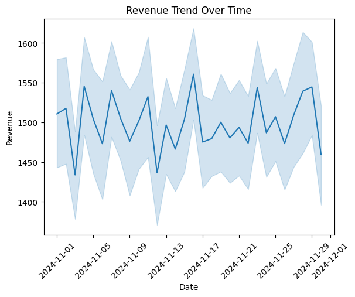

```python
sns.lineplot(x='Ad_Date', y='Sale_Amount', data=df)

plt.title("Revenue Trend Over Time")
plt.xlabel("Date")
plt.ylabel("Revenue")
plt.xticks(rotation=45)
plt.show()
```

Campaign Revenue Comparison # Identify best-performing marketing campaigns.

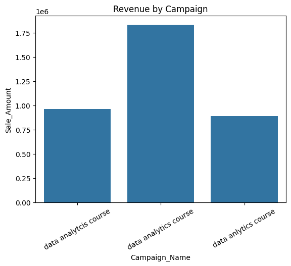

```python
campaign_rev = df.groupby('Campaign_Name')['Sale_Amount'].sum().reset_index()

sns.barplot(x='Campaign_Name', y='Sale_Amount', data=campaign_rev)

plt.title("Revenue by Campaign")
plt.xticks(rotation=30)
plt.show()
```

Device Performance Analysis #Which device converts best: mobile, desktop, tablet.

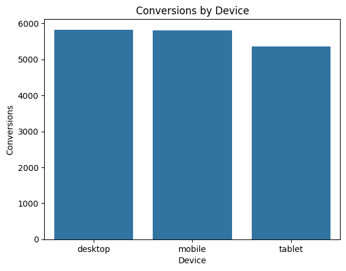

```python
device_perf = df.groupby('Device')['Conversions'].sum().reset_index()

sns.barplot(x='Device', y='Conversions', data=device_perf)

plt.title("Conversions by Device")
plt.show()
```

Top Keywords Driving Conversions #Which keywords bring actual sales.

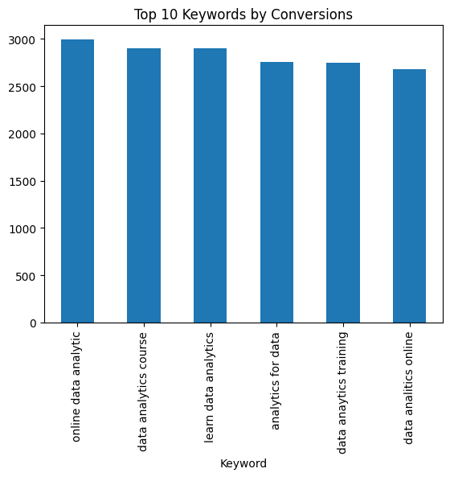

```python
keyword_conv = df.groupby('Keyword')['Conversions'].sum().sort_values(ascending=False).head(10)

keyword_conv.plot(kind='bar')

plt.title("Top 10 Keywords by Conversions")
plt.show()
```

CTR Distribution (Ad Engagement) # Understand how users interact with ads.

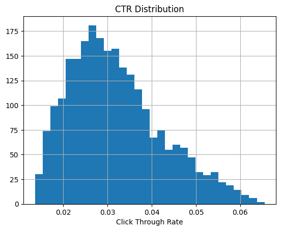

```python
df['CTR'].hist(bins=30)

plt.title("CTR Distribution")
plt.xlabel("Click Through Rate")
plt.show()
```

Cost vs Revenue (ROI Analysis) #Check marketing return efficiency.

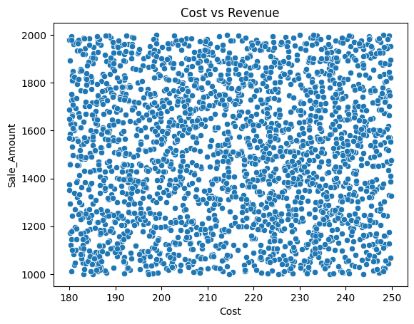

```python
sns.scatterplot(x='Cost', y='Sale_Amount', data=df)

plt.title("Cost vs Revenue")
plt.show()
```

Conversion Funnel (Marketing Funnel) #Shows where users drop off in the funnel.

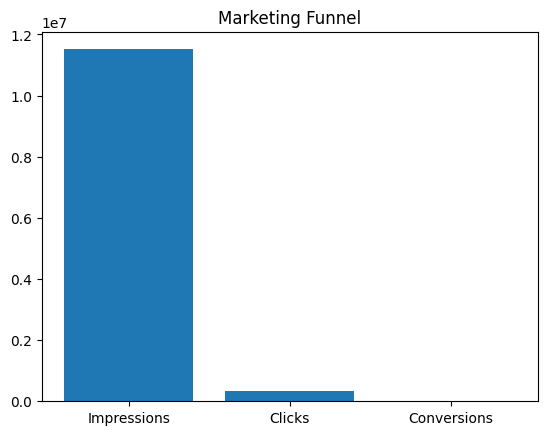

```python
funnel = [
    df['Impressions'].sum(),
    df['Clicks'].sum(),
    df['Conversions'].sum()
]

labels = ['Impressions','Clicks','Conversions']

plt.bar(labels, funnel)

plt.title("Marketing Funnel")
plt.show()
```

CPA by Campaign (Efficiency Analysis)

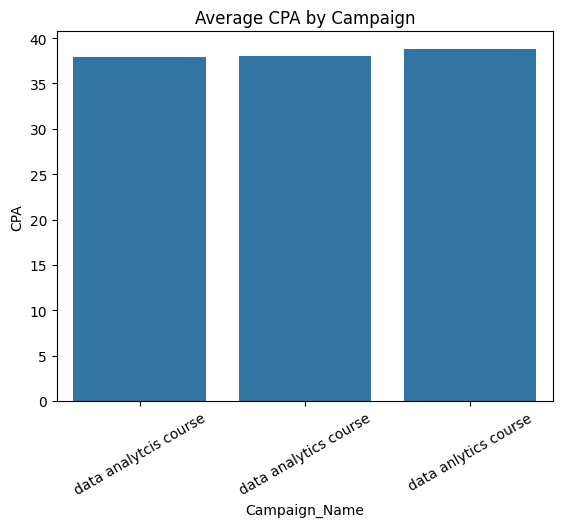

```python
campaign_cpa = df.groupby('Campaign_Name')['CPA'].mean().reset_index()

sns.barplot(x='Campaign_Name', y='CPA', data=campaign_cpa)

plt.title("Average CPA by Campaign")
plt.xticks(rotation=30)
plt.show()
```

```python
ROAS Performance (Return on Ad Spend) # Which campaigns generate highest return.
```

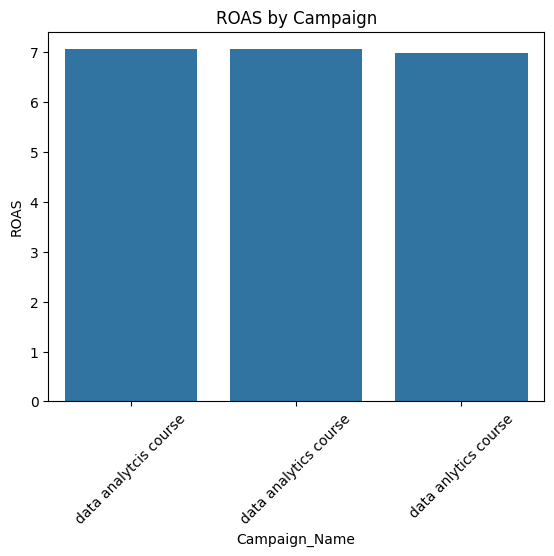

```python
campaign_roas = df.groupby('Campaign_Name')['ROAS'].mean().reset_index()

sns.barplot(x='Campaign_Name', y='ROAS', data=campaign_roas)

plt.title("ROAS by Campaign")
plt.xticks(rotation=45)
plt.show()
```

Geographic Revenue Analysis #Identify best geographic markets.

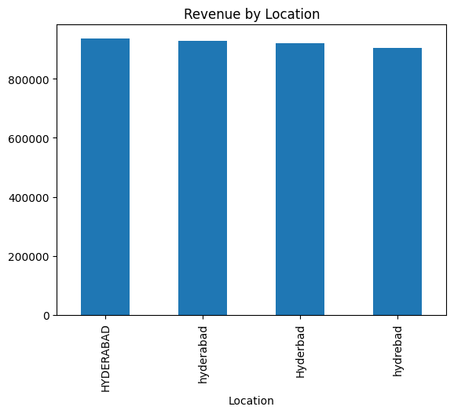

```python
location_sales = df.groupby('Location')['Sale_Amount'].sum().sort_values(ascending=False)

location_sales.plot(kind='bar')

plt.title("Revenue by Location")
plt.show()
```

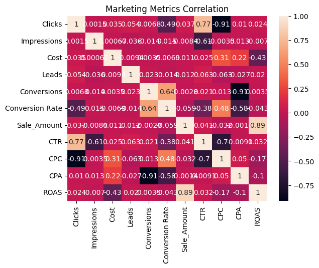

```python
sns.heatmap(df.corr(numeric_only=True), annot=True)

plt.title("Marketing Metrics Correlation")
plt.show()
```